# Лабораторная работа № 8

Презентация

Гайдук Софья Сергеевна

1032253645@rudn.ru

Российский университет дружбы народов

2026-03-30

## Title

# Информация

## Докладчик

- Гайдук Софья Сергеевна
- студент
- Российский университет дружбы народов им. П. Лумумбы
- 1032253645@rudn.ru
- https://github.com/SofiaGayduk/study_2025-2026_os-intro

## Цель работы

Ознакомление с инструментами поиска файлов и фильтрации текстовых данных. Приобретение практических навыков: по управлению процессами (и заданиями), по проверке использования диска и обслуживанию файловых систем.

## Выполнение лабораторной работы

## Запись в файл

Осуществим вход в систему, используя соответствующее имя пользователя. Запишем в файл file.txt названия файлов, содержащихся в каталоге /etc. Допишем в этот же файл названия файлов, содержащихся в нашем домашнем каталоге (рис. 1, рис. 2, рис. 3).

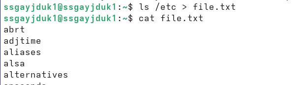

Figure 1: image1

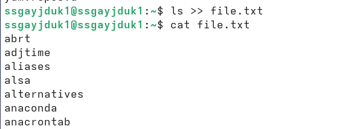

Figure 2: image2

## Запись в файл

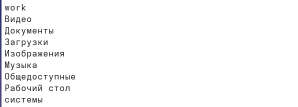

Figure 3: image3

## Вывод имен

Выведим имена всех файлов из file.txt, имеющих расширение .conf, после чего запишем их в новый текстовой файл conf.txt (рис. 4, рис. 5).

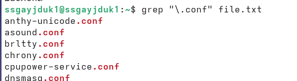

Figure 4: image4

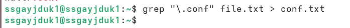

Figure 5: image5

## Определение файлов

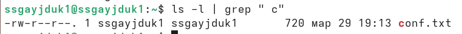

Figure 6: image6

## Запуск в фоновом режиме

Запустим в фоновом режиме процесс, который будет записывать в файл ~/logfile файлы, имена которых начинаются с log (рис. 9, рис. 10).

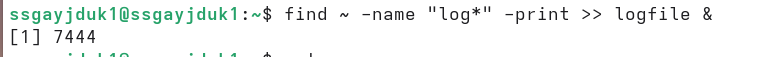

Figure 9: image9

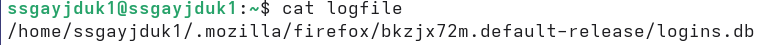

Figure 10: image10

## gedit

Запустим из консоли в фоновом режиме редактор gedit (рис. 12).

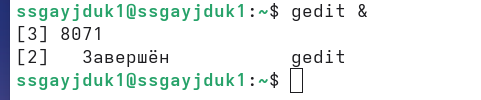

Figure 12: image12

## gedit

Определим идентификатор процесса gedit, используя команду ps, конвейер и фильтр grep. Сделаем это несколькими вариантами (рис. 13).

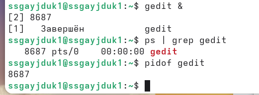

Figure 13: image13

## kill

Прочтем справку (man) команды kill, после чего используем её для завершения процесса gedit (рис. 14).

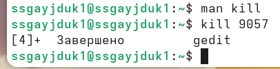

Figure 14: image14

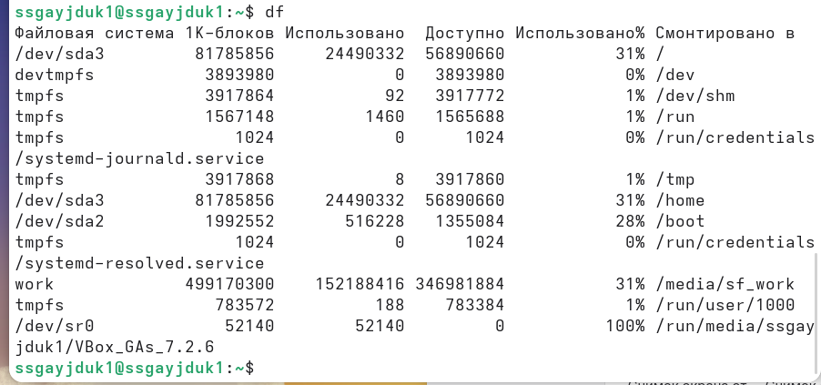

Figure 15: image15

## find

Воспользовавшись справкой команды find, выведим имена всех директорий, имеющихся в нашем домашнем каталоге (рис. 17).

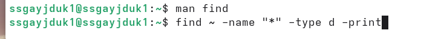

Figure 17: image17

## Выводы

Мы ознакомлились с инструментами поиска файлов и фильтрации текстовых данных. Приобрели практических навыков: по управлению процессами (и заданиями), по проверке использования диска и обслуживанию файловых систем.

## Список литературы

1.Kulyabov. Лабораторная работа № 8. Поиск файлов. Перенаправление ввода-вывода. Просмотр запущенных процессов. RUDN